# Design Bitcoin Blockchain

Author

Affiliation

Jingda Yang

Georgetown University

[figure not shown]

BITCOIN

# 1 Introduction

The objective of this work is to delve into the intricacies of designing the Bitcoin blockchain, providing a comprehensive overview that spans from the underlying data structures to the desired functionalities that make Bitcoin a secure and decentralized system. Through a systematic exploration, we aim to unveil the mechanisms that ensure integrity and transparency in Bitcoin transactions, setting a precedent for the development of future blockchain technologies.

As we embark on this journey, readers will be introduced to the core concepts that underpin the blockchain, including the blockchain data structure itself, the cryptographic principles that secure it, and the consensus algorithms that maintain its integrity. Furthermore, we will explore the practical aspects of blockchain technology by walking through the implementation details, starting with the importation of necessary libraries and culminating in the definition of a Block class

**Objective**

To design and implement a blockchain data structure using Python, emphasizing understanding each component and its integration.

Fundamentally, a blockchain is an amalgamation of several technologies. I would like to see each of those technologies built and combined in this assignment.

# 2 Blockchain Data Structure

Each blockchain starts with a Genesis block. We will need to define this block function in object-oriented Python. We need to implement the `hash_block()`, which computes the hash value of this block based on how we initialize it. This function takes in no parameters.

## 2.1 Desired Functionality:

- Concatenate string representations of all the class variables
- Computes the SHA256 hash of this concatenation.

## 2.2 Importing Libraries

Import the following libraries before developing the function `hashlib`, `random`, `datetime`, `date`, `time`, `ipyparallel`, `numpy`, `matplotlib`.

```python
# import necessary libraries according to the requirements
import hashlib as hasher
import random
import datetime as date
import time
import numpy as np
import matplotlib.pyplot as plt
```

## 2.3 Block Class

The main `Block` components we will need:

1. index - The index of the block on the chain (zero-indexed)
2. timestamp – T time that the block was added to the chain
3. data - The data the block contains (Usually points to the root of a Merkel tree, but we can use a common thread for this)
4. previous_hash - The hash value of the previous block
5. hash - The hash of this block is computed using the hash_block function
6. nonce - The variable value that we change to alter the hash output (Default value = 0, irrelevant in this section)

We will need to define two functions in class Object named Block, and the two functions are `__init__()` (called dunder init) and `blockHash()`.

The dunder `init` function takes six inputs, including a self, from the list above (#5 above is the output). The `blockHash()` function takes inputs from dunder `init` in a string form, appends them, and encodes them through a `SHA256` function.

```python
# define a Block class to create a block
# this class has init method to initialize the block, and blockHash method to hash the block
class Block:
    def __init__(self, index, timestamp, data, previous_hash, nonce = 0):
        self.index = index
        self.timestamp = timestamp
        self.data = data
        self.nonce = nonce # set nonce as default, so it will not apply to the first section.
        self.previous_hash = previous_hash
        self.hash = self.blockHash()

# define a blockHash method to hash the block

    def blockHash(self):
        sha = hasher.sha256()
        blockHash = (str(self.index) +
                    str(self.timestamp) +
                    str(self.data) +
                    str(self.previous_hash) +
                    str(self.nonce))
        blockHash = blockHash.encode('utf-8')
        sha.update(blockHash)
        return sha.hexdigest()
```

**note**

This `class block` will be used to generate the genesis block and the subsequent blocks in the blockchain. The `blockHash()` function will be used to hash the block.

## 2.4 Generate the Genesis Block

```python
# Generate the genesis block hash
# Here I set some initial values for the genesis block
block_time =  '2023-12-30 23:59:59'
data = 'Blockchain For Data Science'
previous_hash = '9136cfeb0c77b41e1e86cb9940ca9bb65f7aca4e8e366a8ecf9226b735e0c323'
index = 1
new_block = Block(index, block_time, data, previous_hash)
print(new_block.hash)
```

```
9861ae4c1781b2161cd3f9557829aa4cc886465948fec8ba29fc5fe47925aa0d
```

**note**

We use the information above to validate the `class block` function. We can also call the initial block Genesis Block.

The Genesis Block is the first block in the blockchain. It is the only block that does not have a previous block. The genesis block is hardcoded into the blockchain software. This Genesis Block should contain the following information: Timestamp, Data, Previous Hash, and Index. We can use `class block` to generate the genesis block and show the hash value of the genesis block.

## 2.5 Test Function

Code below will validate the block hash.

```python
#In this function, we will validate the block hash.
def block_validation(index, block_time, data, previous_hash):
    new_block = Block(index, block_time, data, previous_hash)
    check_string = '9861ae4c1781b2161cd3f9557829aa4cc886465948fec8ba29fc5fe47925aa0d'
    print_statement = "This is a valid Block" if str(new_block.hash) == check_string else "Please Check your work, this is incorrect."
    print(print_statement)

block_time = '2023-12-30 23:59:59'
data = 'Blockchain For Data Science'
previous_hash = '9136cfeb0c77b41e1e86cb9940ca9bb65f7aca4e8e366a8ecf9226b735e0c323'
index = 1
# this initial genesis block information is the same as the previous chunk.

block_validation(index, block_time, data, previous_hash)
```

```
This is a valid Block
```

**note**

The message above shows that the block hash is valid. This is the expected output. If the output is different, please check the code.

# 3 Creating a chain out of single blocks

Now that we have our class `Block()` completed, we need to build a chain out of them. Define a function that creates a `genesis_block()`. This will generate the first block of the chain. Then create the function `new_block()`, which builds a new block on top of a given block.

The `genesis_block()` function has `index = 0`, `timestamp = Now` (whenever the function is being called), `data = "Genesis Block"`, `previous_hash = "0"` and a `return`. Be careful with `NOW` function (it requires `datetime` from `date` package). `New_block()` function will take the following inputs:

1. `Last_block` = an instance of class Block, the block we’re building our next block on top of.
2. `index` = index of last_block + 1
3. `timestamp` = Now (whenever the function is being called)
4. `data` = `"Block {index} generated"` (for example, block with index 5 would have data: “Block 5 generated”)
5. `previous_hash` = hash of `last_block`

## 3.1 Generating the Genesis Block

```python
# Creates the first block with current time and generic data
def create_genesis_block():
    # Manually construct a block with index zero and arbitrary previous hash using Block() class
    genesis_block = Block(0, date.datetime.now(), "Genesis Block", "0")
    return genesis_block

#Function that creates the next block, given the last block on the chain you want to mine on
def next_block(last_block, nonce=0):
    # Your code for next block here
    this_index = last_block.index + 1
    this_timestamp = date.datetime.now()
    this_data = "Block " + str(this_index) + " generated" # modified the example string output.
    this_prevhash = last_block.hash
    this_block = Block(this_index, this_timestamp, this_data, this_prevhash)
    return this_block
```

**note**

Genesis Block is the first block in the blockchain. It is the only block that does not have a previous block. The genesis block is hardcoded into the blockchain software. This Genesis Block should contain the following information: Timestamp, Data, Previous Hash, and Index. We can use `class block` to generate the genesis block and show the hash value of the genesis block.

Once the function is generated, use the following code to test the validity

```python
# Validate the genesis block here
def genesis_validation(genesis_block):
    block_1 = next_block(genesis_block)

    if (block_1.index == 1 and
    block_1.data == "Block 1 generated" and
    block_1.previous_hash == genesis_block.hash and
    str(type(block_1.timestamp)) == "<class 'datetime.datetime'>"):
        print("Valid Genesis block")

    else:
        print("Check the code, not a valid genesis block:(")

genesis_block = create_genesis_block()

genesis_validation(genesis_block)
```

```
Valid Genesis block
```

# 4 Generating complete Blockchain

We now have a complete program required to create a chain. We need variables (and/or functions) `blockchain`, `previous_block`, and `num_blocks` to generate a chain for a specified number of blocks. Use `num_blocks` as 10. Blockchain is used to initialize with the genesis block inside, initialized as a list. The variables and functions will: 1. `previous_block` – points to the genesis block. 2. `num_blocks` – the specific number of blocks to add to the chain. For the assignment, use 10.

We want to complete the implementation of the function `complete_chain()`. It will take the above three inputs, which correspond to the initializations that we made earlier.

1. The function will need a for loop from 0 to num blocks. Inside the loop, we will use `newblock()` function from #2 to add to the block list.
2. Once the block is generated, we will append it to the blockchain array generated above.
3. We will now set the block from step 1 as `previous_block`.
4. Print `(“the block #{} is added to the blockchain”.format(addedblock.index))`
5. `Print(“Hash : {}\n”.format(addedblock.hash))`

## 4.1 Initialize the chain

```python
# Create the blockchain and add the genesis block
blockchain = [create_genesis_block()] # this is similar to genesis_block from before

# Create our initial reference to previous block which points to the genesis block
previous_block = blockchain[0]# get the first block from the blockchain object

# How many blocks should we add to the chain after the genesis block
num_blocks = 10 # Change this to 10 for the assignment
```

**note**

First we set the number of blocks to 10. We then create the blockchain and add the genesis block to it. We set the initial reference to the previous block, which points to the genesis block.

## 4.2 Create a chain function

```python
def complete_chain(num_blocks, blockchain, previous_block):
    # Add blocks to the chain
    for i in range(0, num_blocks):
        #adding the block
        block_to_add = next_block(previous_block)     # use next block function
        # append this block to the blockchain list
        blockchain.append(block_to_add)
        # Set the block as the previous block for the next iteration
        previous_block = block_to_add# Set the previous block to the block you just added

        # Tell everyone about it! show the block number and hash
        print("the block #{} is added to the blockchain!".format(block_to_add.index))
        print("Hash: {}\n".format(block_to_add.hash))
```

## 4.3 Print the Chain

```python
example_chain = complete_chain(num_blocks, blockchain, previous_block)
print(example_chain)
```

```
the block #1 is added to the blockchain!
Hash: 51700cd47b576dce415f509a481f24116210ed21b5686f0b06238310d3397bb2

the block #2 is added to the blockchain!
Hash: ed29c5998d6b2dd9807c9c43d022d7bf13cb1bcc60713cbdbe6a100e395be367

the block #3 is added to the blockchain!
Hash: fa5fb6074af185c79cb0f775a946c81a637d221a6021cc49bc4f99eacbbf0ff9

the block #4 is added to the blockchain!
Hash: a289500740e48280df957dd617b2179509fc3d91d0eace7fe55508280d79463e

the block #5 is added to the blockchain!
Hash: 5fd9869d2ff8601f2e7db95556a21a3aae69293726e9eb5977259019b87a294e

the block #6 is added to the blockchain!
Hash: 3db86f13df84d73d128950cd692da0006023e32f047f11817f97dafcf9b92754

the block #7 is added to the blockchain!
Hash: 3eeb2615c4c910a816d039daaf8e4d1f59226978b63c4bab6c924f690550ae0b

the block #8 is added to the blockchain!
Hash: 6089db68c5cc5b9bdde478582cbaa7bf12009f6e39b986ce1b22da315ef1eddf

the block #9 is added to the blockchain!
Hash: f5d4c5595a196c08d4d23c5637f8226f519d0b5e1cbc51d9c839e6d8bfbd87e0

the block #10 is added to the blockchain!
Hash: af796adf6c5ddeccc0a44a596c011b550775ced22746654292e4db4df7cfbce6

None
```

You will see ten blocks with their hashes.

**note**

The function `complete_chain()` will generate a chain of blocks. The function will take the number of blocks, the blockchain, and the previous block as inputs. It will generate a chain of blocks and print the block number and hash for each block.

# 5 Nonce and Difficulty

Let’s make it more realistic in assignment two by adding the proof-of-work consensus mechanism that Bitcoin’s Blockchain uses. We need to look at two concepts for proof of work and proof of stake simulation: **Nonce** and **Difficulty**.

## 5.1 Nonce

1. The Nonce – A randomly generated value added to the blocks to vary block hashes
2. The network specifies the difficulty. We will set this. It defines the valid hashes (number of) out of all possible values. Greater difficulty indicates a lower number of valid hashes.

### 5.1.1 Define function generate_nonce()

There are multiple ways to develop `generate_nonce()`. We can use the following methods since this is a regular n-digit random number. Although we just need one method, you might be able to explore the ones you like. Computers can not generate true random numbers, so they use pseudo-random numbers.

1. We can use `randint` function to generate a number between a and b. There is a limitation to this. What is that limitation?
2. `nonce = secrets.token_urlsafe()` generates cryptographically strong random numbers.
3. and many others, explore.

```python
import secrets

def generate_nonce(length=20):
    # Your code for nonce here
    digits = '0123456789' # use numbers from 0-9
    nonce = ''.join(secrets.choice(digits) for _ in range(length)) # use secrets.choice to generate a random number
    # I first set digits = '0123456789' and then use secrets.choices() to generate a random number
    # The reason why we do not only use randint(0,9) is that a single digit is not cryptographically secure,
    # and it can be easily guessed by an attacker.
    return nonce
```

**note**

`nonce` is a random number that is used to vary the hash of the block. The function `generate_nonce()` generates a random number of a specified length. This function will be used to generate the nonce for the blocks in the blockchain.

```python
print(generate_nonce())
```

```
90485066817226803915
```

### 5.1.2 Define function generate_difficulty_bound()

This is a bit harder to conceptualize. In Bitcoin, we usually look for the number of zeros before a hash to define the difficulty.

The function takes only one argument, `generate_difficulty_bound(difficulty=1)`. 1. Initiate an empty string that will hold our difficulty hash 2. We now need to generate a hex string that starts with zeros of size equal to “difficulty.” So if `difficulty =1`, then the string will have 1 leading zero, `difficulty=2` will have 2 leading zeros. Use a `for` loop to generate this and append it to the string in 1. 3. In the same function, define a `for` loop to append a hex character, `F`. This loop should run for the range of length (64-difficulty). 4. We also need to prepend `0x` to the now completely formed string. 5. This function should return the integer value from the string with a `base 16` (since this is a hex code).

```python
# define a function to generate difficulty bound
def generate_difficulty_bound(difficulty=1):
    # Assign an empty string to store the difficulty hash
    diff_str = ''
    # for loop to generate the leading zeros (appending to the empty string)
    for i in range(difficulty):
        diff_str += '0'
      # append the leading zeros to the empty string

    # for loop to generate the trailing Fs (appending to the empty string)
    for i in range(64 - difficulty):
        diff_str += 'F'
      # append the trailing Fs to the empty string
  # prepend 0x to the string
    diff_str = '0x' + diff_str # "0x" needs to be added at the front to specify that it is a hex representation
    # print(diff_str)  # we can also print it to check the complete string.
    return (int(diff_str, 16))  # Specifies that we want to create an integer of base 16 (as opposed to the default  base 10)
```

**note**

The function `generate_difficulty_bound()` generates a difficulty bound for the blockchain. The difficulty bound is a hex string that specifies the number of leading zeros in the hash. The function takes a difficulty level as an argument and returns the difficulty bound as an integer.

```python
# print an example of the difficulty bound
print(generate_difficulty_bound(1))
```

```
7237005577332262213973186563042994240829374041602535252466099000494570602495
```

### 5.1.3 Engineer a nonce given the previous block’s hash and difficulty

The function `find_next_block()` tries different blocks with the same data, index etc. but different nonces that satisfy the difficulty metric specified. This function takes three arguments `find_next_block(last_block, difficulty, nonce_length)` 1. Create variable `start_time = time.process_time()`. 2. Create a variable that stores `generate_difficulty_bound(difficulty)`. 3. Create a variable that sets `next_block(last_block)`. 4. Create a variable that stores the hashes tried and set the start value to 1 (`hashtried=1`). You will increment this in every loop. 5. Create a while loop that conditionally tests the new block’s hash (in hex, so `int(new_block.hash, 16)`) to be greater than the `difficultybound` variable from #2 above. 6. Create a variable nonce to store `generate_nonce(nonce_length value)` 7. Create a new_block variable that used `Block()` function from before. 8. Increment `hashtried` by 1 (`hashtried +=1`) 9. `time_taken = time.process_time() – start_time` will calculate the time for finding the block. 10. Return the value of time taken, hashtried, and new block

```python
# Given a previous block and a difficulty metric, find a nonce that results in a lower hash value
def find_next_block(last_block, difficulty, nonce_length):
    # Assign the result of 'generate_difficulty_bound' with 'difficulty' as the argument to 'difficulty_bound'
    difficulty_bound = generate_difficulty_bound(difficulty)

    # Capture the start time using 'time.process_time()'
    start = time.process_time()

    # Generate the next block based on 'last_block' using an appropriate function
    new_block = next_block(last_block)

    # Initialize the 'hashes_tried' counter to 1
    hashes_tried = 1

    # Implement a while loop that continues until the hash of 'new_block'
    # is less than or equal to 'difficulty_bound'.
    # Inside the loop:
    #   - Generate a new nonce using 'generate_nonce' with 'nonce_length'.
    #   - Create a new instance of 'Block' with the new nonce and update 'new_block'.
    #   - Increment 'hashes_tried' by 1 after each iteration.
    while int(new_block.hash, 16) > difficulty_bound:
        nonce = generate_nonce(nonce_length)
        new_block = Block(new_block.index, new_block.timestamp, new_block.data, new_block.previous_hash, nonce)
        hashes_tried += 1

    time_taken = time.process_time() - start
    return(time_taken, hashes_tried, new_block)
```

**note**

The function `find_next_block()` finds a nonce that satisfies the difficulty metric for the blockchain. The function takes a previous block, a difficulty level, and a nonce length as arguments. It returns the time taken to find the block, the number of hashes tried, and the new block.

# 6 Consensus Mechanism

## 6.1 Proof-of-Work

To create Bitcoin’s proof-of-work, we need to find a nonce that satisfies the difficulty metric. We will use the `find_next_block()` function from above to find the nonce. We will use the following steps to simulate proof-of-work:

1. Create a function `create_blockchain` that takes variables
   1. `num_blocks`
   2. `difficulty`
   3. `blockchain`
   4. `previous_block`
   5. `nonce_length`
   6. `broadcast=1`
2. Initiate two arrays to store `hash` and `time` so we can record the details.
3. Initiate a `for` loop to run for the number of blocks `(0, numblocks)`
   1. Set the `timetaken`, `hashestried`, `block_to_add` to take values from `find_next_block` function from Assignment 1.
   2. Append `block_to_add` to the blockchain array
   3. Set `previousblock` to be a newly generated block (`block_to_add`)
   4. Append hash tried to `hasharray`
   5. Append time taken to `timearray`
4. Time to broadcast this to the network `(broadcast=1, default value)` is a binary input that prints:
   1. Block number added to the chain
   2. Number of hashes tried before solving the puzzle
   3. Time to find the block
   4. Hash of the current block
   5. Returns the hash and time arrays

Given the following data, generate a blockchain with 10 blocks and a difficulty between 3-7 (the higher, the better; use Google Colab).

```python
# Create the blockchain and add the genesis block
blockchain = [create_genesis_block()]

# Set the initial reference to the previous block, pointing to the genesis block
previous_block = blockchain[0]

# Specify the number of blocks to add to the chain (excluding the genesis block)
num_blocks = 10

# Define the difficulty level for the PoW algorithm
difficulty = 3 # I only set the difficulty to 3. It takes a long time to run the code if I set it to 5.

# Set the length of the nonce to be generated
nonce_length = 20

# Create a blockchain using the PoW algorithm
def create_pow_blockchain(num_blocks, difficulty, blockchain, previous_block, nonce_length, broadcast=1):
    hash_array = []
    time_array = []
    for i in range(0, num_blocks):
        # Use the find_next_block function to mine a new block
        time_taken, hashes_tried, block_to_add = find_next_block(previous_block, difficulty, nonce_length)

        # Add the newly mined block to the blockchain
        blockchain.append(block_to_add)

        # Update the reference to the previous block
        previous_block = block_to_add

        # Record the number of hashes tried and the time taken for each block
        hash_array.append(hashes_tried)
        time_array.append(time_taken)
        if broadcast:
            print("Block #{} added to the chain".format(block_to_add.index))
            print("{} Hashes Tried!".format(hashes_tried))
            print("Time taken to find block: {}".format(time_taken))
            print("Hash: {}\n".format(block_to_add.hash))
    return hash_array, time_array

# Test function above
hash_array, time_array = create_pow_blockchain(num_blocks, difficulty, blockchain, previous_block, nonce_length)
```

```
Block #1 added to the chain
4818 Hashes Tried!
Time taken to find block: 0.10655499999999973
Hash: 0001808ecd02df9a539259f34cd07d6f47e834ac1fe44b32c109b2f21403dbd0

Block #2 added to the chain
1375 Hashes Tried!
Time taken to find block: 0.030126000000000097
Hash: 00048ca1e31e9b8bfc5e064a2ed3648aa7ee1d0e6e9190a168e4ddf4cdf15ed8

Block #3 added to the chain
2890 Hashes Tried!
Time taken to find block: 0.063021
Hash: 000c0d92460390028929941e94ad7ee2d7abea543d582406b5825acc52e973e9

Block #4 added to the chain
311 Hashes Tried!
Time taken to find block: 0.006994000000000167
Hash: 000031f3f5a7a8ca80119c8a1d998695acbb65a1178d61897dc39f4a46f505ad

Block #5 added to the chain
6153 Hashes Tried!
Time taken to find block: 0.13319100000000006
Hash: 0007d180ab9b42dfac06170e1c95b45944904631b16b54b6fabdc503a7d31517

Block #6 added to the chain
5307 Hashes Tried!
Time taken to find block: 0.1178539999999999
Hash: 0000909c1673bca1af2981c9ec59a71068e3e65b17bedda8f571558b56ebbcc4

Block #7 added to the chain
4429 Hashes Tried!
Time taken to find block: 0.09938099999999972
Hash: 00055d116c5fd156251ef93de91f3ec34f6b025d5a9de9f41c95c072020cd3c0

Block #8 added to the chain
1890 Hashes Tried!
Time taken to find block: 0.04126800000000008
Hash: 0007125e43a3bac406dbaa1bac0fdf356583539fe0a71824ddeab3b9e05fb42c

Block #9 added to the chain
2865 Hashes Tried!
Time taken to find block: 0.06238900000000003
Hash: 000e9016e0b404fbb91e5154f86990573cfa02675bacc6e6aab648b90987607a

Block #10 added to the chain
1080 Hashes Tried!
Time taken to find block: 0.023460000000000036
Hash: 0008fa33793455e01e508401b1f7a9b0ec703412d156bb823a3b97001808552b
```

**note**

The function `create_pow_blockchain()` generates a blockchain using the proof-of-work algorithm. The function takes the number of blocks, the difficulty level, the blockchain, the previous block, the nonce length, and a broadcast flag as arguments. It returns the number of hashes tried and the time taken to find each block.

### 6.1.1 Test the Blockchain

```python
# Test the Blockchain
def test_pow_blockchain(blockchain_pow, num_blocks):
    correct = True
    bound = generate_difficulty_bound(difficulty)
    if len(blockchain_pow) != num_blocks + 1:
        correct = False
    for i in range(len(blockchain_pow) - 1):
        if blockchain_pow[i + 1].previous_hash != blockchain_pow[i].hash:
            correct = False
            break
        if int(blockchain_pow[i + 1].hash, 16) > bound:
            correct = False
            break
    print_statement = "PASSED!!! Move on to the next Part" if correct else "FAILED!!! Try Again :("
    print(print_statement)

test_pow_blockchain(blockchain, num_blocks)
```

```
PASSED!!! Move on to the next Part
```

**note**

The function `test_pow_blockchain()` tests the blockchain generated using the proof-of-work algorithm. The function takes the blockchain and the number of blocks as arguments. It checks if the blockchain is valid by verifying the previous hash and the hash of each block.

# 7 Distributed Network and Computing Power

Using the following function, we will generate multiple miners. Naive miner class that races with other miners to see who can get a certain number of blocks first.

```python
class MinerNodeNaive:
    def __init__(self, name, compute):
        self.name = name
        self.compute = compute

    def try_hash(self, diff_value, chain):
        last_block = chain[-1]
        difficulty = generate_difficulty_bound(diff_value)
        date_now = date.datetime.now()
        this_index = last_block.index + 1
        this_timestamp = date_now
        this_data = "Hey! I'm block " + str(this_index)
        this_hash = last_block.hash
        new_block = Block(this_index, this_timestamp, this_data, this_hash)
        if int(new_block.hash, 16) < difficulty:
            chain.append(new_block)
            # Tell everyone about it!
            print("Block #{} has been added to the blockchain!".format(new_block.index))
            print("Block found by: {}".format(self.name))
            print("Hash: {}\n".format(new_block.hash))
```

**note**

First, we generate the name of the miner, and then the compute power that particular miner has in the first part. The **name** serves as an identifier for the miner within the blockchain network. In contrast, the **compute** attribute measures the miner’s capability to perform the computational work required for mining blocks.

In the second part, we must find the difficulty value and look at the chain. we will use the last_block, which is the last block in the chain, and the difficulty, which is the difficulty of the chain, then the current time, index order, and the data. As long as the difficulty is greater than the hash block, we will append the new block to the chain, and then print the details of the block.

In summary, the function of this class is initializing miner attributes, creating a new block based on specific criteria, and adding it to the blockchain if it meets the difficulty requirements.

## 7.1 Generate multiple mining peers

Generate five mining peers with different computing power. Use a `for` loop to generate an array of 5 miners; miners = [mineer1, mineer2, mineer3, mineer4, mineer5] 1. Use `comp_pow` = `random.randint` to generate random numbers and assign them to five peers. 2. For each miner in miners and each number in `comp_pow`, assign `MinerNodeNaive()` function 3. **Use for loop instead of line-by-line generation; set `compute` a random number between 1-15.**

```python
miners = []

# Use `comp_pow` = `random.randint` to generate random numbers and assign them to five peers.
comp_pow = [random.randint(1, 15) for _ in range(1, 6)]

for i, power in enumerate(comp_pow, start=1):
    #create a new miner with a name and a random compute power
    miner = MinerNodeNaive("miner{}".format(i), power)
    miners.append(miner)

    #show the miner's name and compute power
    print(miner.name, miner.compute)
```

```
miner1 8
miner2 3
miner3 15
miner4 13
miner5 14
```

## 7.2 Create a compute and mining simulation

This function will create a random mining pool. Define `compute_simulation(miners)` 1. Create an empty array `com_array` 2. Using a `miner` in `miners` and that miner’s computing power, replicate the miner and append it to `com_array`, generating the random peer group. 3. Return this compute array

```python
def create_compute_simulation(miner_array):
    compute_array = []
    # Iterate through each miner in miner_array
    for miner in miner_array:

    # For each miner, append their name to compute_array based on their compute power
        for i in range(miner.compute):
            compute_array.append(miner.name)
    return compute_array

compute_simulation_array = create_compute_simulation(miners)
# Use the function above to generate the compute simulation array

random.shuffle(compute_simulation_array)
# Shuffle the array to simulate random mining
```

**note**

The function `create_compute_simulation()` generates a random mining pool based on the computing power of the miners. The function takes an array of miners as an argument and returns an array of miners based on their compute power.

## 7.3 Difficulty list

Generate an array, `difficult_list`, of random numbers between 2 to 6 spanning the length of the chain (number of blocks).

```python
# generate the difficult list.
chain_length = 10
blockchain_distributed = [create_genesis_block()]
genesis_block_dist = blockchain_distributed[0]
chain_difficulty = [random.randint(2, 6) for i in range(chain_length)]
print(chain_difficulty)
```

```
[3, 4, 5, 3, 5, 2, 4, 5, 6, 4]
```

**note**

The generated `chain_difficulty` list contains random difficulty levels between 2 and 6 for each block in the blockchain. The difficulty level determines the number of leading zeros in the hash of each block.

## 7.4 Simulation

Using the parameters below generate a blockchain

1. For the length of the chain (`range(len(numblocks))`) and while blockchain is smaller than `numblocks+2`.
2. Set `next_miner = miner 2`
3. Sample from miners to pick one miner
4. For miner in miners, check if the sampled miner is the same as the miner name; if yes, then set that miner as `next_miner`
5. Calculate hash using the next miner’s hash function (given above)

```python
#simulation of the blockchain mining
for i in range(len(chain_difficulty)):
    while len(blockchain_distributed) < i + 2:
        next_miner_str = random.sample(compute_simulation_array, 1)[0]
        next_miner = miners[1] # miner[1] means the second miner in the list
        for miner in miners:
            if next_miner_str == miner.name:
                next_miner = miner
        next_miner.try_hash(chain_difficulty[i], blockchain_distributed)
```

```
Block #1 has been added to the blockchain!
Block found by: miner3
Hash: 000cdb68f2bfb5083a3448b4b82b272ce0cc88b4b3fa6a26ae82ec5f75a3063b

Block #2 has been added to the blockchain!
Block found by: miner5
Hash: 0000dc2f69d75d30e7b27a36d437973842ee70d8860fbc8276ef02cf24df5930

Block #3 has been added to the blockchain!
Block found by: miner5
Hash: 000004297aea6043800d15856bbecfc00300cc77ba9eec69dc0a310712b27298

Block #4 has been added to the blockchain!
Block found by: miner4
Hash: 00013b98c01ea03855ac3b3fe8c541ce315b527033e20272d3a53655f5ed0375

Block #5 has been added to the blockchain!
Block found by: miner3
Hash: 000006ffa9705dfbb290a55a04933fba2c4a5baaa7f19193c9ab7457afe6c749

Block #6 has been added to the blockchain!
Block found by: miner1
Hash: 000ddffed0340c962a6d559f57e8db1e444b9b3bd49dcf576acecc8da27e4f54

Block #7 has been added to the blockchain!
Block found by: miner4
Hash: 000007faa901180ba62d0f3bd8e020042746beac148e13a2c5a3622c6e61576e

Block #8 has been added to the blockchain!
Block found by: miner2
Hash: 000006f13b223741b841fd864b9de105faaee050be431bb02a587767e2bd7888

Block #9 has been added to the blockchain!
Block found by: miner2
Hash: 0000000b1fda23dc1e9c737ec744d6b4b0cdca0d5290ffc24616d398fdd8cb5c

Block #10 has been added to the blockchain!
Block found by: miner5
Hash: 0000556af1cfb6412c0e5f80cb99db25a98a29af0a8abcdee7e1fc6ed74d52c2
```

# 8 Analytics on the Blockchain Data

For each difficulty level below, use the given data and `create_blockchain()` function from the last assignment

## 8.1 Extract the hash array and time array

```python
import numpy as np
import matplotlib.pyplot as plt
from tqdm import tqdm

blockchain = [create_genesis_block()]
previous_block = blockchain[0]
num_blocks = 10
nonce_length = 20

# List of different difficulty levels to analyze
# difficulty_levels = [1, 2, 3, 4, 5, 6, 7]
difficulty_levels = [1, 2, 3, 4, 5]
#I only set the difficulty to 5. It takes a long time to run the code if I set it to 7.

# Arrays to store the mean hash and time for each difficulty level
mean_arr_hash = []
mean_arr_time = []

# Arrays to store the full hash and time arrays for each difficulty level
full_hash_arrays = []
full_time_arrays = []

# Iterate over each difficulty level with a progress bar
for difficulty in tqdm(difficulty_levels, desc="Calculating difficulties"):
    hash_array, time_array = create_pow_blockchain(num_blocks, difficulty, blockchain, previous_block, nonce_length, 0)
    print("Difficulty Level: {} complete".format(difficulty))

    #store the full hash and time arrays
    full_hash_arrays.append(hash_array)
    full_time_arrays.append(time_array)

    # Calculate and store the mean values
    mean_arr_hash.append(np.mean(hash_array))
    mean_arr_time.append(np.mean(time_array))
```

```
Difficulty Level: 1 complete
Difficulty Level: 2 complete
Difficulty Level: 3 complete
Difficulty Level: 4 complete
Difficulty Level: 5 complete
```

## 8.2 Plot all 5 hash arrays on one plot

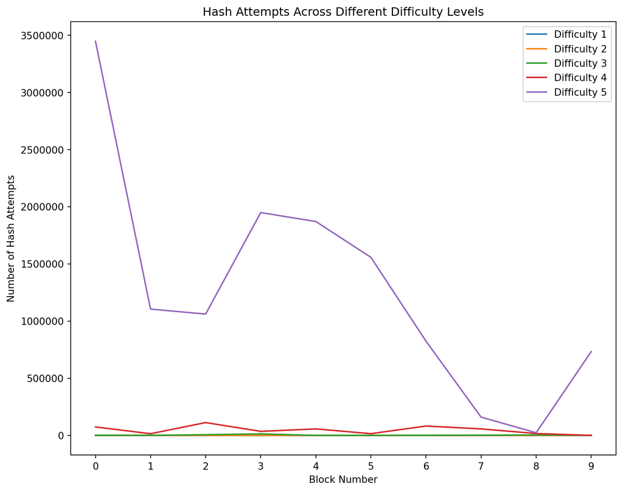

Figure 1: Hash Attempts Across Different Difficulty Levels

```python
#extracting each hash array
hash_array_0 = full_hash_arrays[0]
hash_array_1 = full_hash_arrays[1]
hash_array_2 = full_hash_arrays[2]
hash_array_3 = full_hash_arrays[3]
hash_array_4 = full_hash_arrays[4]

plt.figure(figsize=(10, 8))

plt.plot(hash_array_0, label="Difficulty 1")
plt.plot(hash_array_1, label="Difficulty 2")
plt.plot(hash_array_2, label="Difficulty 3")
plt.plot(hash_array_3, label="Difficulty 4")
plt.plot(hash_array_4, label="Difficulty 5")

#disable scientific notation
ax = plt.gca()
ax.get_yaxis().get_major_formatter().set_scientific(False)

#set the x-axis to be the block number
plt.xticks(range(len(hash_array_0)))

plt.title("Hash Attempts Across Different Difficulty Levels")
plt.xlabel("Block Number")
plt.ylabel("Number of Hash Attempts")
plt.legend()
plt.show()
```

**note**

The plot above shows the number of hash attempts required to mine each block for different difficulty levels. The x-axis represents the block number, while the y-axis represents the number of hash attempts. The plot provides insights into the mining process and the computational effort required to mine blocks at different difficulty levels.

## 8.3 Plot all 5 time arrays on one plot

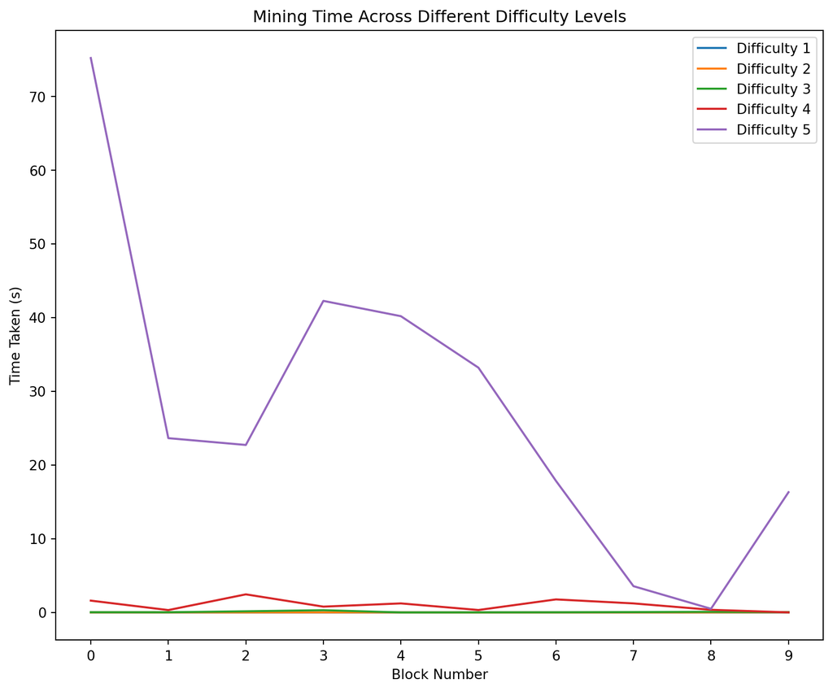

Figure 2: Mining Time Across Different Difficulty Levels

```python
# Plotting the mean time values
# extracting each time array
time_array_0 = full_time_arrays[0]
time_array_1 = full_time_arrays[1]
time_array_2 = full_time_arrays[2]
time_array_3 = full_time_arrays[3]
time_array_4 = full_time_arrays[4]

# plotting each time array individually
plt.figure(figsize=(10, 8))

plt.plot(time_array_0, label="Difficulty 1")
plt.plot(time_array_1, label="Difficulty 2")
plt.plot(time_array_2, label="Difficulty 3")
plt.plot(time_array_3, label="Difficulty 4")
plt.plot(time_array_4, label="Difficulty 5")

# set the x-axis to be the block number
plt.xticks(range(len(hash_array_0)))

plt.title("Mining Time Across Different Difficulty Levels")
plt.xlabel("Block Number")
plt.ylabel("Time Taken (s)")
plt.legend()
plt.show()
```

**note**

The plot above shows the time taken to mine each block for different difficulty levels. The x-axis represents the block number, while the y-axis represents the time taken in seconds. The plot provides insights into the mining process and the time required to mine blocks at different difficulty levels.

## 8.4 Plot average of time plot

```python
# Calculate the factors of difficulty increase
diff_factors = []
for i in range(1, len(mean_arr_hash)):
    diff_factor = mean_arr_hash[i] / mean_arr_hash[i - 1]
    diff_factors.append(diff_factor)
    print(f"Factor of difficulty increase from {i} to {i + 1}: {diff_factor:.2f}")
```

```
Factor of difficulty increase from 1 to 2: 14.65
Factor of difficulty increase from 2 to 3: 11.21
Factor of difficulty increase from 3 to 4: 14.55
Factor of difficulty increase from 4 to 5: 27.32
```

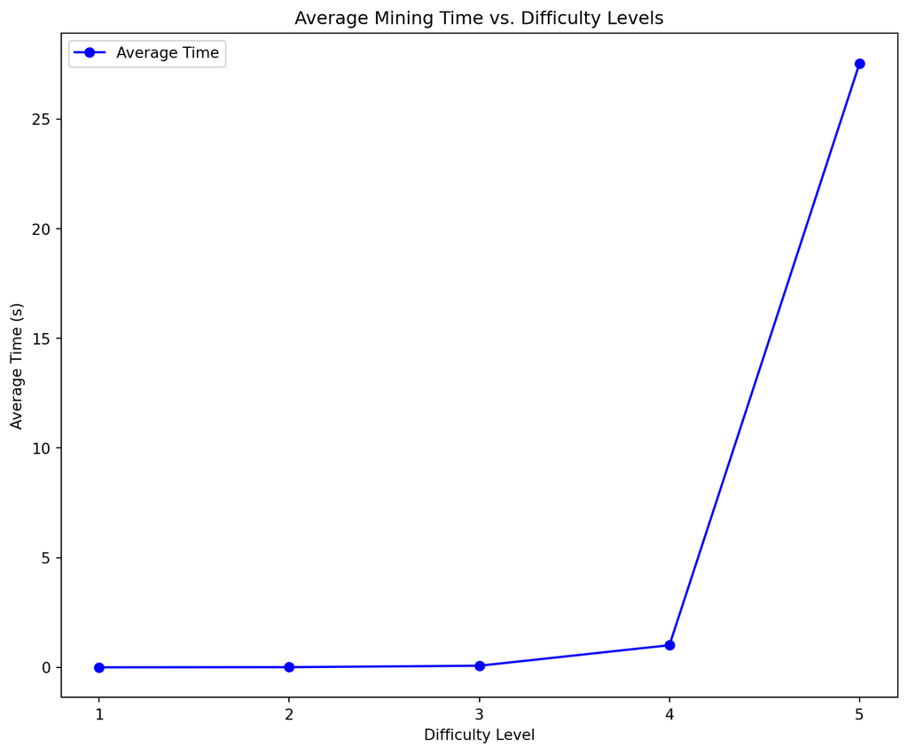

Figure 3: Average Mining Time vs. Difficulty Levels

```python
plt.figure(figsize=(10, 8))

#plot the mean time against difficulty levels
plt.plot(difficulty_levels, mean_arr_time, marker='o', linestyle='-', color='b', label='Average Time')

#set x-axis ticks to show difficulty_levels
plt.xticks(difficulty_levels)

plt.title('Average Mining Time vs. Difficulty Levels')
plt.xlabel('Difficulty Level')
plt.ylabel('Average Time (s)')
plt.legend()

plt.show()
```

**note**

The plot above shows the average time taken to mine a block for different difficulty levels. The x-axis represents the difficulty level, while the y-axis represents the average time taken in seconds. The plot provides insights into the mining process and the time required to mine blocks at different difficulty levels.

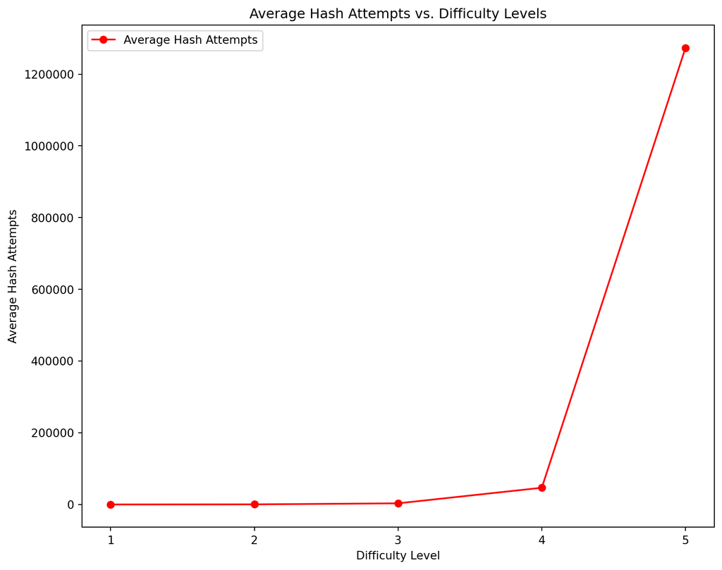

Figure 4: Average Hash Attempts vs. Difficulty Levels

```python
#
#set figure size
plt.figure(figsize=(10, 8))

#plot the mean hash arrays against difficulty levels
plt.plot(difficulty_levels, mean_arr_hash, marker='o', linestyle='-', color='r', label='Average Hash Attempts')

#disable scientific notation
ax = plt.gca()
ax.get_yaxis().get_major_formatter().set_scientific(False)

#set x-axis ticks to show difficulty_levels
plt.xticks(difficulty_levels)

plt.title('Average Hash Attempts vs. Difficulty Levels')
plt.xlabel('Difficulty Level')
plt.ylabel('Average Hash Attempts')
plt.legend()

plt.show()
```

**note**

The plot above shows the average number of hash attempts required to mine a block for different difficulty levels. The x-axis represents the difficulty level, while the y-axis represents the average number of hash attempts. The plot provides insights into the mining process and the computational effort required to mine blocks at different difficulty levels.

# 9 Conclusion

As difficulity increases, the time taken to mine a block increases. The number of hash attempts also increases with the difficulty level.